# Now You CanadaKnow

Joanna Rae Pepin

@CoffeeBaseball

[www.joannapepin.com](https://joannapepin.com/)

## About

These figures are my effort to learn about Canadian families, with an emphasis on gender and work. You are welcome to use them for your own teaching or learning. You can directly download the figures in .png formats or use the scripts to recreate and modify them as you desire.

## Figures

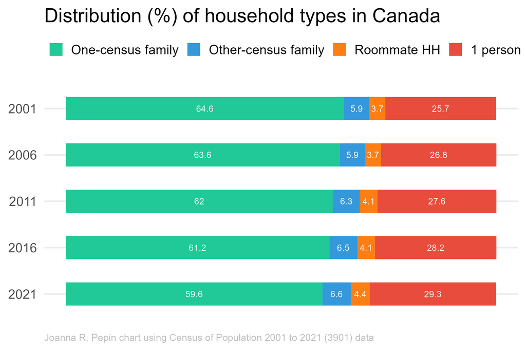

[download](https://github.com/jrpepin/Now-You-CanadaKnow/blob/main/figs/hh.png) | [code](https://github.com/jrpepin/Now-You-CanadaKnow/blob/main/R/households.R)

#### Definitions:

[**One census family**](https://www12.statcan.gc.ca/census-recensement/2021/ref/dict/az/Definition-eng.cfm?ID=fam004): a married couple and the children, if any, of either and/or both spouses; a couple living common law and the children, if any, of either and/or both partners; or a parent of any marital status in a one‑parent family with at least one child living in the same dwelling and that child or those children. All members of a particular census family live in the same dwelling. Children may be biological or adopted children regardless of their age or marital status as long as they live in the dwelling and do not have their own married spouse, common‑law partner or child living in the dwelling. Grandchildren living with their grandparent(s) but with no parents present also constitute a census family.

**Other census family households**: multiple generations of a family, two or more census families, or one census family living with additional persons not in a census family

**Roommate HH**: two or more people living together, among which none are part of a census family

**1 person**: one-person household

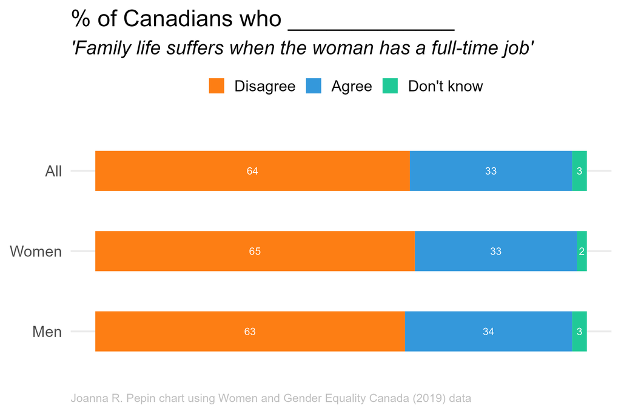

[download](https://github.com/jrpepin/Now-You-CanadaKnow/blob/main/figs/famsuffer.png) | [code](https://github.com/jrpepin/Now-You-CanadaKnow/blob/main/R/familysuffers.R)

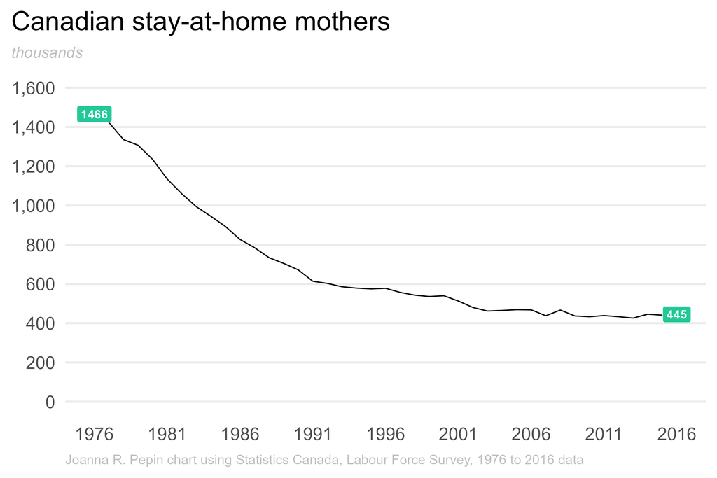

[download](https://github.com/jrpepin/Now-You-CanadaKnow/blob/main/figs/sahmom.png) | [code](https://github.com/jrpepin/Now-You-CanadaKnow/blob/main/R/sahmom.R)

#### Definitions:

[**Stay-at-home parent**](https://www150.statcan.gc.ca/n1/pub/11-630-x/11-630-x2016007-eng.htm#def1): a person in a couple family with at least one child under the age of 16 at home, who did not have a job or business, was not looking for work, was not attending school, and was not permanently unable to work during the survey reference week; parents on maternity or parental leave are not considered to be stay-at-home parents if they have a job to which they will return—they are considered employed and absent from work.

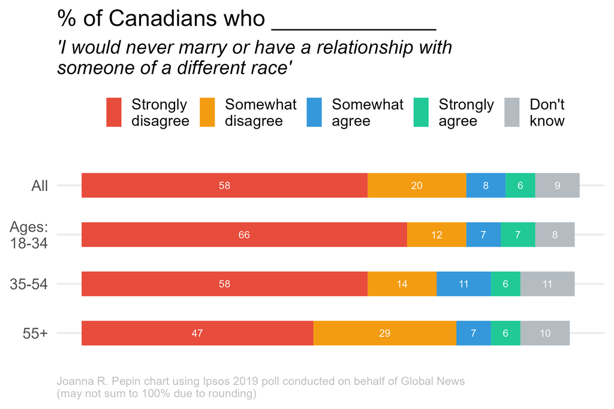

[download](https://github.com/jrpepin/Now-You-CanadaKnow/blob/main/figs/marrace.png) | [code](https://github.com/jrpepin/Now-You-CanadaKnow/blob/main/R/marrace.R)

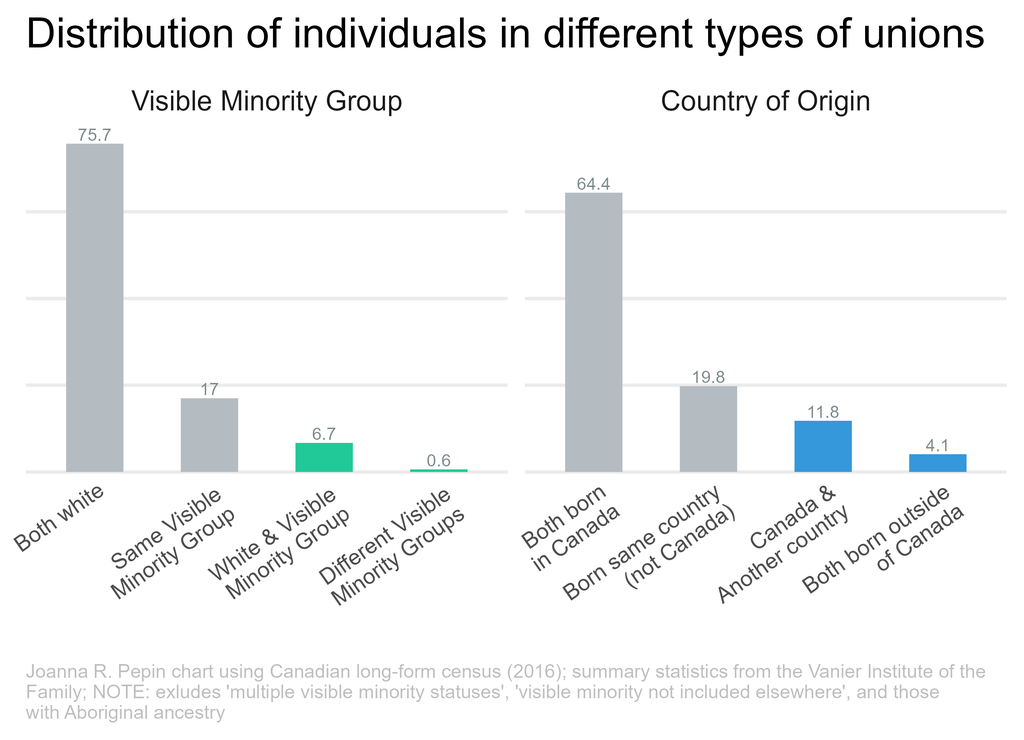

[download](https://github.com/jrpepin/Now-You-CanadaKnow/blob/main/figs/mixed.png) | [code](https://github.com/jrpepin/Now-You-CanadaKnow/blob/main/R/mixed.R)

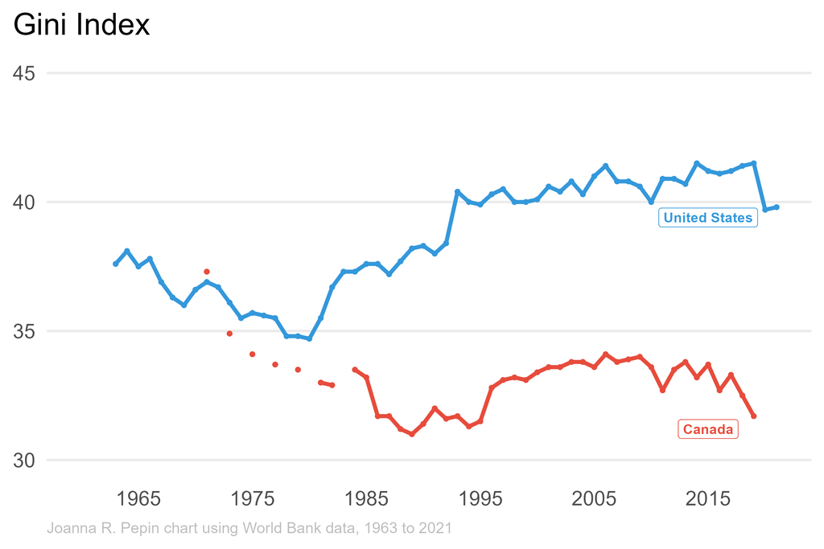

[download](https://github.com/jrpepin/Now-You-CanadaKnow/blob/main/figs/gini.png) | [code](https://github.com/jrpepin/Now-You-CanadaKnow/blob/main/R/gini.R)

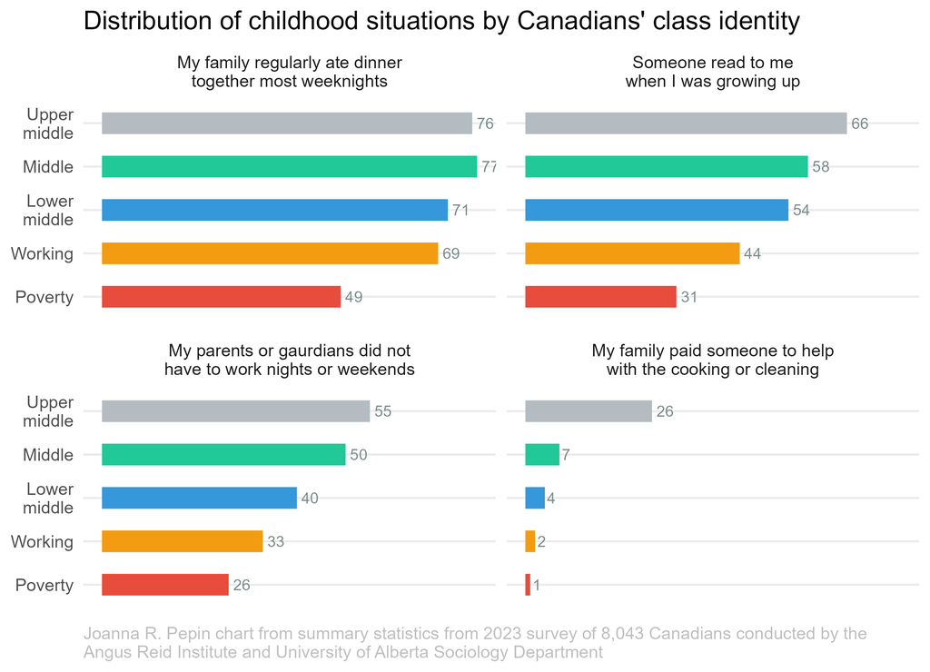

[download](https://github.com/jrpepin/Now-You-CanadaKnow/blob/main/figs/class.png) | [code](https://github.com/jrpepin/Now-You-CanadaKnow/blob/main/R/class.R)